# DSDA 1995

Data Science and Society using R

Lecture 12 | Tidy and Relational Data

## Plan for Today

- Explore data R with `Tidyverse`
- Continue our discussion of `tidy` data
- Discuss `Relational` data
- In class activity

## Separating

- `separate()` pulls apart one column into multiple columns, by splitting wherever a separator character appears

```r
table3
```

```
# A tibble: 6 × 3
  country      year rate
  <chr>       <dbl> <chr>
1 Afghanistan  1999 745/19987071
2 Afghanistan  2000 2666/20595360
3 Brazil       1999 37737/172006362
4 Brazil       2000 80488/174504898
5 China        1999 212258/1272915272
6 China        2000 213766/1280428583
```

- Notice the `rate` column
  - It contains both cases and population variables, and we need to split it into two variables

## Separate

- `separate()` takes the name of the column to separate, and the names of the columns to separate into

```r
table3 %>%
  separate(rate, into = c("cases", "population"))
```

```
# A tibble: 6 × 4
  country      year cases  population
  <chr>       <dbl> <chr>  <chr>
1 Afghanistan  1999 745    19987071
2 Afghanistan  2000 2666   20595360
3 Brazil       1999 37737  172006362
4 Brazil       2000 80488  174504898
5 China        1999 212258 1272915272
6 China        2000 213766 1280428583
```

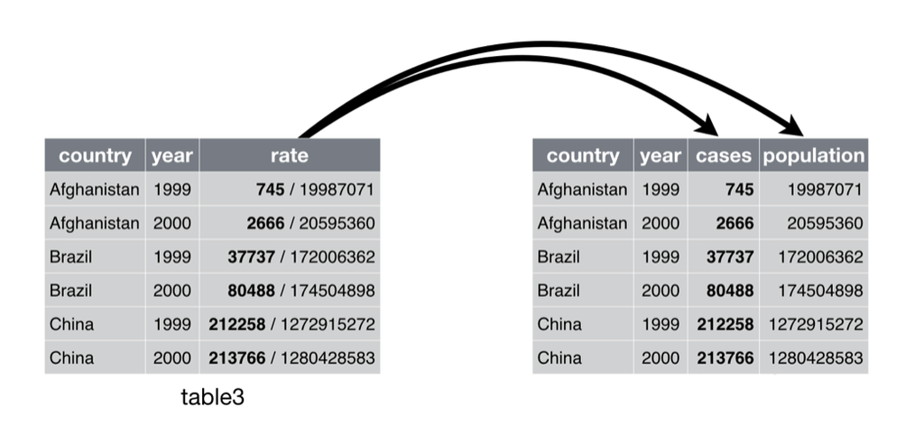

## Separate

- By default, `separate()` will split values wherever it sees a non-alphanumeric character (i.e. a character that isn’t a number or letter)
  - For example, in the code above, `separate()` split the values of rate at the forward slash characters
- If you wish to use a specific character to separate a column, you can pass the character to the `sep` argument of `separate()`

```r
table3 %>%
  separate(rate, into = c("cases", "population"), sep = "/")
```

```
# A tibble: 6 × 4
  country      year cases  population
  <chr>       <dbl> <chr>  <chr>
1 Afghanistan  1999 745    19987071
2 Afghanistan  2000 2666   20595360
3 Brazil       1999 37737  172006362
4 Brazil       2000 80488  174504898
5 China        1999 212258 1272915272
6 China        2000 213766 1280428583
```

## Unite

- `unite()` is the inverse of `separate()`: it combines multiple columns into a single column

[figure not shown]

## Unite

- We can use `unite()` to rejoin the century and year columns

```r
table5
```

```
# A tibble: 6 × 4
  country     century year  rate
  <chr>       <chr>   <chr> <chr>
1 Afghanistan 19      99    745/19987071
2 Afghanistan 20      00    2666/20595360
3 Brazil      19      99    37737/172006362
4 Brazil      20      00    80488/174504898
5 China       19      99    212258/1272915272
6 China       20      00    213766/1280428583
```

```r
table5 %>%
  unite(new, century, year)
```

```
# A tibble: 6 × 3
  country     new   rate
  <chr>       <chr> <chr>
1 Afghanistan 19_99 745/19987071
2 Afghanistan 20_00 2666/20595360
3 Brazil      19_99 37737/172006362
4 Brazil      20_00 80488/174504898
5 China       19_99 212258/1272915272
6 China       20_00 213766/1280428583
```

- In this case we also need to use the `sep` argument
- The default will place an underscore (_) between the values from different columns

```r
table5 %>%
  unite(new, century, year, sep = "")
```

```
# A tibble: 6 × 3
  country     new   rate
  <chr>       <chr> <chr>
1 Afghanistan 1999  745/19987071
2 Afghanistan 2000  2666/20595360
3 Brazil      1999  37737/172006362
4 Brazil      2000  80488/174504898
5 China       1999  212258/1272915272
6 China       2000  213766/1280428583
```

## Relational Data

- In many data science jobs, you will have access to multiple tables of data
- Your job will be to combine these tables to answer questions of interest
- Collectively, multiple tables are called relational data
- Individually, the datasets are meaningful; but the relationship between the datasets is more meaningful
- Relational data often maintained in a database

## Relational Data

- We will use the `nycflights13` package to learn about relational data
- `nycflights13` contains four tibbles that are related to the flights table that you used in data transformation

```r
library(nycflights13)
```

- `airlines` lets you look up the full carrier name from its abbreviated code

```r
airlines
```

```
# A tibble: 16 × 2
   carrier name
   <chr>   <chr>
 1 9E      Endeavor Air Inc.
 2 AA      American Airlines Inc.
 3 AS      Alaska Airlines Inc.
 4 B6      JetBlue Airways
 5 DL      Delta Air Lines Inc.
 6 EV      ExpressJet Airlines Inc.
 7 F9      Frontier Airlines Inc.
 8 FL      AirTran Airways Corporation
 9 HA      Hawaiian Airlines Inc.
10 MQ      Envoy Air
11 OO      SkyWest Airlines Inc.
12 UA      United Air Lines Inc.
13 US      US Airways Inc.
14 VX      Virgin America
15 WN      Southwest Airlines Co.
16 YV      Mesa Airlines Inc.
```

- `airports` gives information about each airpot, identified by the `faa` airport code

```r
airports
```

```
# A tibble: 1,458 × 8
   faa   name                             lat    lon   alt    tz dst   tzone
   <chr> <chr>                          <dbl>  <dbl> <dbl> <dbl> <chr> <chr>
 1 04G   Lansdowne Airport               41.1  -80.6  1044    -5 A     America/…
 2 06A   Moton Field Municipal Airport   32.5  -85.7   264    -6 A     America/…
 3 06C   Schaumburg Regional             42.0  -88.1   801    -6 A     America/…
 4 06N   Randall Airport                 41.4  -74.4   523    -5 A     America/…
 5 09J   Jekyll Island Airport           31.1  -81.4    11    -5 A     America/…
 6 0A9   Elizabethton Municipal Airport  36.4  -82.2  1593    -5 A     America/…
 7 0G6   Williams County Airport         41.5  -84.5   730    -5 A     America/…
 8 0G7   Finger Lakes Regional Airport   42.9  -76.8   492    -5 A     America/…
 9 0P2   Shoestring Aviation Airfield    39.8  -76.6  1000    -5 U     America/…
10 0S9   Jefferson County Intl           48.1 -123.    108    -8 A     America/…
# ℹ 1,448 more rows
```

- `planes` gives information about each plane, identified by its `tailnum`

```r
planes
```

```
# A tibble: 3,322 × 9
   tailnum  year type              manufacturer model engines seats speed engine
   <chr>   <int> <chr>             <chr>        <chr>   <int> <int> <int> <chr>
 1 N10156   2004 Fixed wing multi… EMBRAER      EMB-…       2    55    NA Turbo…
 2 N102UW   1998 Fixed wing multi… AIRBUS INDU… A320…       2   182    NA Turbo…
 3 N103US   1999 Fixed wing multi… AIRBUS INDU… A320…       2   182    NA Turbo…
 4 N104UW   1999 Fixed wing multi… AIRBUS INDU… A320…       2   182    NA Turbo…
 5 N10575   2002 Fixed wing multi… EMBRAER      EMB-…       2    55    NA Turbo…
 6 N105UW   1999 Fixed wing multi… AIRBUS INDU… A320…       2   182    NA Turbo…
 7 N107US   1999 Fixed wing multi… AIRBUS INDU… A320…       2   182    NA Turbo…
 8 N108UW   1999 Fixed wing multi… AIRBUS INDU… A320…       2   182    NA Turbo…
 9 N109UW   1999 Fixed wing multi… AIRBUS INDU… A320…       2   182    NA Turbo…
10 N110UW   1999 Fixed wing multi… AIRBUS INDU… A320…       2   182    NA Turbo…
# ℹ 3,312 more rows
```

- `weather` gives the weather at each NYC airport for each hour

```r
weather
```

```
# A tibble: 26,115 × 15
   origin  year month   day  hour  temp  dewp humid wind_dir wind_speed
   <chr>  <int> <int> <int> <int> <dbl> <dbl> <dbl>    <dbl>      <dbl>
 1 EWR     2013     1     1     1  39.0  26.1  59.4      270      10.4
 2 EWR     2013     1     1     2  39.0  27.0  61.6      250       8.06
 3 EWR     2013     1     1     3  39.0  28.0  64.4      240      11.5
 4 EWR     2013     1     1     4  39.9  28.0  62.2      250      12.7
 5 EWR     2013     1     1     5  39.0  28.0  64.4      260      12.7
 6 EWR     2013     1     1     6  37.9  28.0  67.2      240      11.5
 7 EWR     2013     1     1     7  39.0  28.0  64.4      240      15.0
 8 EWR     2013     1     1     8  39.9  28.0  62.2      250      10.4
 9 EWR     2013     1     1     9  39.9  28.0  62.2      260      15.0
10 EWR     2013     1     1    10  41    28.0  59.6      260      13.8
# ℹ 26,105 more rows
# ℹ 5 more variables: wind_gust <dbl>, precip <dbl>, pressure <dbl>,
#   visib <dbl>, time_hour <dttm>
```

## Relational Data

- The relationship between these tables

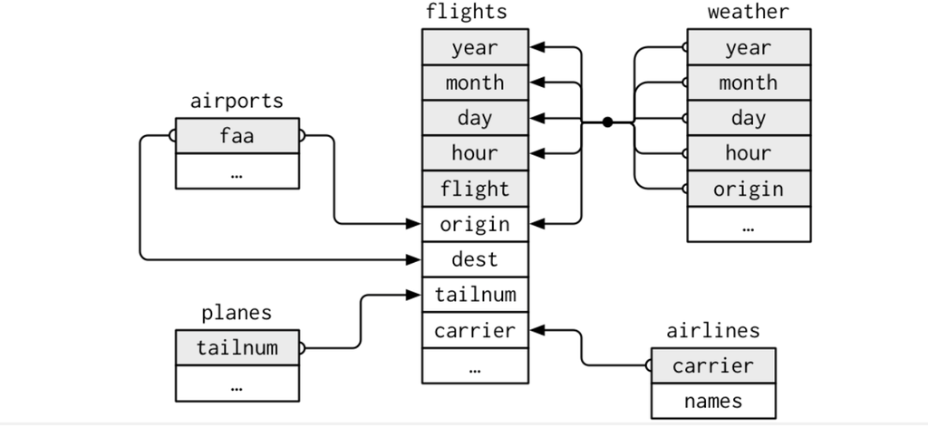

- How do these four datasets connect to `ncyflights13`
  - flights connects to planes via a single variable, tailnum
  - flights connects to airlines through the carrier variable
  - flights connects to airports in two ways: via the origin and dest variables
  - flights connects to weather via origin (the location), and year, month, day and hour (the time)

## Keys

- The variables used to connect each pair of tables are called keys
  - A key is a variable (or set of variables) that uniquely identifies an observation
- Primary Key
  - uniquely identifies an observation in its own table. For example, planes$tailnum is a primary key because it uniquely identifies each plane in the planes table
- Foreign Key
  - uniquely identifies an observation in another table. For example, flights$tailnum is a foreign key because it appears in the flights table where it matches each flight to a unique plane
- A variable can be both a primary and a foreign key
- Once you’ve identified the primary keys in your tables, it’s good practice to verify that they do indeed uniquely identify each observation

## Keys

- Use `count()`

```r
planes %>%
  count(tailnum) %>%
  filter(n > 1)
```

```
# A tibble: 0 × 2
# ℹ 2 variables: tailnum <chr>, n <int>
```

```r
weather %>%
  count(year, month, day, hour, origin) %>%
  filter(n > 1)
```

```
# A tibble: 3 × 6
   year month   day  hour origin     n
  <int> <int> <int> <int> <chr>  <int>
1  2013    11     3     1 EWR        2
2  2013    11     3     1 JFK        2
3  2013    11     3     1 LGA        2
```

## Mutating Joins

- Allows us to combine a pair a tables
- It first matches observations by their keys, then copies across variables from one table to the other
- Like `mutate()`, the join functions add variables to the right

```r
flights2 <- flights %>%
  select(year:day, hour, origin, dest, tailnum, carrier)

flights2
```

```
# A tibble: 336,776 × 8
    year month   day  hour origin dest  tailnum carrier
   <int> <int> <int> <dbl> <chr>  <chr> <chr>   <chr>
 1  2013     1     1     5 EWR    IAH   N14228  UA
 2  2013     1     1     5 LGA    IAH   N24211  UA
 3  2013     1     1     5 JFK    MIA   N619AA  AA
 4  2013     1     1     5 JFK    BQN   N804JB  B6
 5  2013     1     1     6 LGA    ATL   N668DN  DL
 6  2013     1     1     5 EWR    ORD   N39463  UA
 7  2013     1     1     6 EWR    FLL   N516JB  B6
 8  2013     1     1     6 LGA    IAD   N829AS  EV
 9  2013     1     1     6 JFK    MCO   N593JB  B6
10  2013     1     1     6 LGA    ORD   N3ALAA  AA
# ℹ 336,766 more rows
```

## Mutating Joins

- What if we wanted to add the full airline name to the `flights2()` data?
  - We can combine the `airlines` and `flights2()` data with `left_join()`

```r
flights2 %>%
  select(-origin, -dest) %>%
  left_join(airlines, by = "carrier")
```

```
# A tibble: 336,776 × 7
    year month   day  hour tailnum carrier name
   <int> <int> <int> <dbl> <chr>   <chr>   <chr>
 1  2013     1     1     5 N14228  UA      United Air Lines Inc.
 2  2013     1     1     5 N24211  UA      United Air Lines Inc.
 3  2013     1     1     5 N619AA  AA      American Airlines Inc.
 4  2013     1     1     5 N804JB  B6      JetBlue Airways
 5  2013     1     1     6 N668DN  DL      Delta Air Lines Inc.
 6  2013     1     1     5 N39463  UA      United Air Lines Inc.
 7  2013     1     1     6 N516JB  B6      JetBlue Airways
 8  2013     1     1     6 N829AS  EV      ExpressJet Airlines Inc.
 9  2013     1     1     6 N593JB  B6      JetBlue Airways
10  2013     1     1     6 N3ALAA  AA      American Airlines Inc.
# ℹ 336,766 more rows
```

## Understanding Joins

**Inner Join**

- An inner join matches pairs of observations whenever their keys are equal

**Outer Join**

- An outer join keeps observations that appear in at least one of the tables
  - There are three types of outer joins
    - Left join: keeps all observations in x
    - Right join: keeps all observations in y
    - full join: keeps all observations in x and y

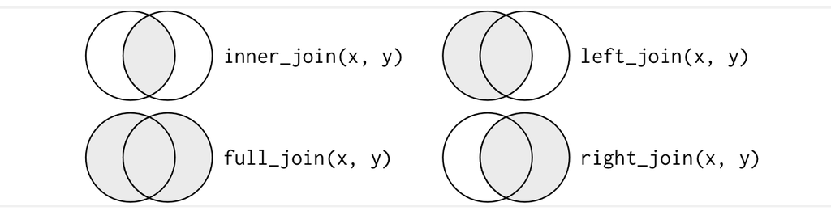

## For Next Class

- Review what you learned today
- Do new set of readings:
  - We are going to continue or discuss of relational data
  - R4DS Chapter 14
  - R4DS Chapter 16
  - R4DS Chapter 17
  - R4DS Chapter 19.3 - 19.6
    - Follow along the exercises with your own computer
- Bring your laptops to class